# Project 3, Path 1: Bioinformatics of Gene Expression

Merrimack College DSE6630: Healthcare & Life Sciences Analytics

Desi Spark (DS), Meghan Holden (MH)

21 June 2026

# 1 Extension of this Project

At the end of Project 3, we advised the shareholders that the results of our modeling efforts should be interpreted cautiously, while these genes are appearing as top importance between both DESeq and nested CV random forest, neither shows statistical importance when looking at both the p-value and adjusted p-values. The stability of the models is not instilling confidence at this point, as each time the models were run at different seeds we saw significantly different results. Our recommendation is to narrow down by moving forward with controlling for an individual timepoint, whereas before we’ve been including time as a feature in our model. Therefore, we deicded to move forward with Path 1 of this project:

> Perform $k$-fold & nested CV Random Forest, as well as hyperparameter tuning, on a different VST from the 30-minute experiment only.

We will use the VST data for the 30-min time point expression data only. Results of the `DESeq` have already been provided so that we can reuse the `findOverlappingGenes()` function again to look at performance. As such, our task is to take this VST, and work through all the same steps as in this first-half of the project. **We will make sure to look at the important features at the end and comment on whether we have any confidence in your results after this change in approach!**

## 1.1 Housekeeping

### 1.1.1 Loading Data

We will begin by loading in the pre-prepared 30-min data in the `data_30min` directory**:

1. `vst_30_min.Rdata` = the 30-min equivalent of the `vsData` object with the VST normalized read counts, formatted and ready to use as in this walk-through.
2. `vst_30_min.txt` = a text file version, which you likely do not need
3. `DESeq_on_30min_Data.Rmd` = an RMD file that was used to generate the 30-min data, plus some exploratory analysis. For the results see #4.
4. `DESeq_on_30_Data.html` = knitted file with some EDA and results to get you better acquainted to the data. Take a look! :)
5. `DESeqResults_30_min.Rdata` = the 30-min equivalent of the `DESeqResults` object that you can use with this walk-through.

```r
#SPARK FILE NAMES
# ## the 30-min equivalent of the `vsData` object with the VST normalized read counts, formatted and ready to use as in this walk-through.
# load("E:/GitHubPract/Merrimack_DSE6630/Team_Directories/epsilon/Module_Projects/Project_3/data_30min/vst_30_min.Rdata")
#
# ## the 30-min equivalent of the `DESeqResults` object that you can use with this walk-through.
# load("E:/GitHubPract/Merrimack_DSE6630/Team_Directories/epsilon/Module_Projects/Project_3/data_30min/DESeqResults_30_min.Rdata")


# NOT SURE IF NEEDED
# load("E:/GitHubPract/Merrimack_DSE6630/Team_Directories/epsilon/Module_Projects/Project_3/data/OOB_RF_Importance.Rdata")   ## Load the OOB RF importance from
#                                             ## Demo_3 for comparison
# load("E:/GitHubPract/Merrimack_DSE6630/Team_Directories/epsilon/Module_Projects/Project_3/data/OOB_SVM_Importance.Rdata")  ## Load the OOB SVM importance from
#                                             ## Demo_3 for comparison


#MH FILE NAMES
## the 30-min equivalent of the `vsData` object with the VST normalized read counts, formatted and ready to use as in this walk-through.
load("C:/Users/User/Documents/GitHub/Merrimack_DSE6630/Merrimack_DSE6630/Team_Directories/epsilon/Module_Projects/Project_3/data_30min/vst_30_min.Rdata")

## the 30-min equivalent of the `DESeqResults` object that you can use with this walk-through.
load("C:/Users/User/Documents/GitHub/Merrimack_DSE6630/Merrimack_DSE6630/Team_Directories/epsilon/Module_Projects/Project_3/data_30min/DESeqResults_30_min.Rdata")
```

### 1.5.2.2 Functions

Bringing in the same functions as the first part of Project3.

#### 1. `doSplits()`

This function quickly and easily performs data partitioning & pre-processing of the datasets, depending on algorithm chosen. This function could also facilitate automated testing of filtering cutoffs or split-ratios by algorithm, if desired.

#### 2. `findOverlappingGenes()`

Function that compares the `DESeq` results at a given log-fold change (LFC) with the list of important genes from an ML classifier. This could again be iterated over to automate collation of results for more automated comparisons.

#### 3. `compareConfusion()`

This function compares the results of confusion matrices by printing them in a table side-by-side. You could also use this to graph your results, if desired.

# 2 Tuning the Random Forest Model

## 2.1 Random Forest Hyperparameters

To begin, we will investigate and tune the hyperparameters for a random forest.

## 2.2 Pre-processing and feature selection

We will set `filterCutoff = 5` and partition data for random forest tuning.

```r
splits <- doSplits(vst = vsData,
                   algorithm = "rf",
                   splitRatio = 0.8,
                   filterCutoff = 5)
```

```
## [1] "After filtering, number of genes in the dataset are: 8553"
```

```r
train <- splits[[1]]
test <- splits[[2]]
```

#### **Question 3b**: Using the annotation I have provided in the function `doSplits()`, explain the parameters chosen and try to explain *why* you think they were chosen, based on what we did in Demo_3. In particular, make sure to explain WHY a filterCutoff of 5 was chosen. (**Hint**: In Demo_3, did we do anything to adjust for genes with low variance in expression?)

DS > algorithm = “rf” is the specific model to use work with the data, random forest. splitRatio = 0.8; We’ll be using 80% of the data for training the model, and the remaining 20% for the testing the algorithm. filterCutoff = 5, This value of the parameter will drop any feature that are nearly constant which are variances that don’t change at all or aren’t useful. This will keep anything with an importance of 5 or higher. This is important for removing unwanted noise as well, so RF can perform even better.

## 2.3 Apply $k$-fold Cross-Validation (CV) to Random Forest

### 2.3.1. Leverage the `trainControl()` and `train()` functions from the `caret` package.

Set the control for $k = 5$ and then run the RF: **NOTE that in our original project this was set to 10**

```r
# Set the CV arguments
kFoldCtrl <- trainControl(method = "cv",    ## for k-fold CV
                          number = 5        ## k
                          )
```

And fit the Random Forest model:

```r
rfCV <- train(Treatment ~.,
               data = train,
               method = "ranger",
               trControl = kFoldCtrl)    ## added in the k-fold CV
```

#### **Question 4**: Explain, in your own words, what a 10-fold CV does here. Is it vital to perform with a random forest? Why or why not?

MH > Cross validation is not vital to randomforest since it already includes out of bag (OOB) to demonstrate model suitibility; however, 10-fold cross validation can help increase confidence, and allows us to compare across other, non-treebased modesls. A 10-fold cross validation divides the training dataet into 10 equal parts and uses the first fold as a validation set and trains on the remianing 9, then repeated for the rest of the folds. Results are averaged to assess performance.  
Source: ISLR, v2, 2021 > While our initial model used 10-fold CV, we are choosing here to do 5 due to the warning: “in nominalTrainWorkflow(x = x, y = y, wts = weights, info = trainInfo, : There were missing values in resampled performance measures.” This warning is not surprising given we only have 14 observations in our training data. We also tested adding in `repeats` = 20 feature into the CV to assit with stability, but did not neccesarily see any improvement as compared to the models tested below, so for memory, we kept it out of the final markdown.

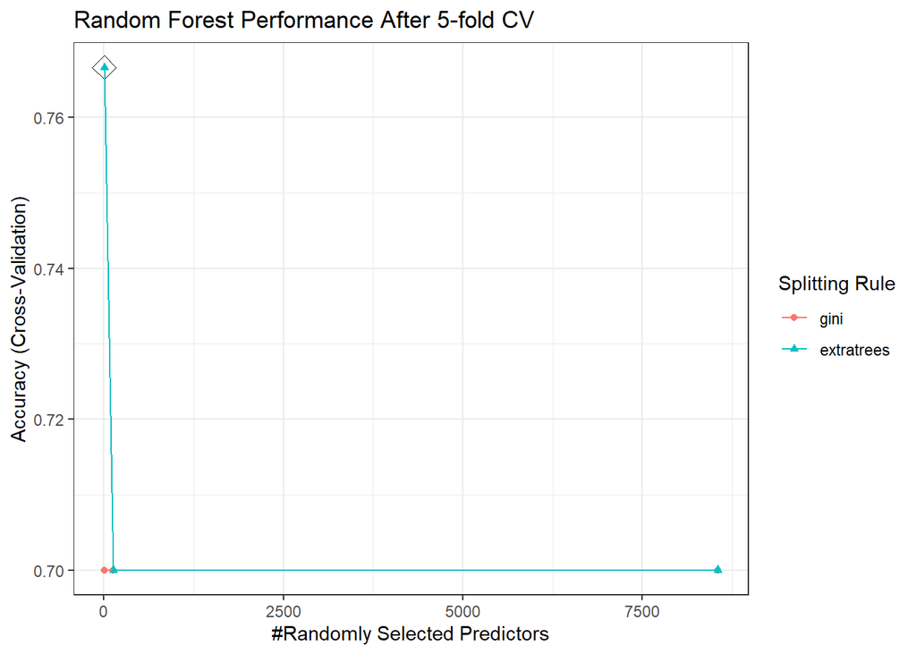

### 2.3.3. Extract best model.

You can also extract the best model as well to get the precise combination of hyperparameters.

Table 1. Hyperparameters of the best Random Forest Model using 5-fold CV

|  | mtry | splitrule | min.node.size |
| --- | --- | --- | --- |
| 2 | 2 | extratrees | 1 |

### 2.3.4. Assess for model stability.

Let’s look at the fold-specific results for our best model. This is essential to assess **stability** of the model.

Table 2. Fold-specific accuracy for the 5-fold CV Random Forest

| Accuracy | Kappa | Resample |
| --- | --- | --- |
| 0.5000000 | 0 | Fold1 |
| 0.3333333 | 0 | Fold3 |
| 1.0000000 | 1 | Fold2 |
| 1.0000000 | 1 | Fold5 |
| 1.0000000 | 1 | Fold4 |

#### **Question 7**: What is the average, minimum, and maximum accuracy values across the ten folds? What does this tell you about the **stability** of the random forest? Is this concerning? Make sure to discuss reasons why there may be instability, if that’s the conclusion you draw.

**Hint**: Think about these results relative to our **sample size**. Would we expect instability in resampling from, among other issues, small sample size alone in this case?

### 2.3.5. Fit the test data to the best tuned model from the 5-fold CV.

Regardless of the decision you made in Question 7, let’s proceed with assessing model performance.

```r
rfCV <- train(Treatment ~.,
               data = train,
               method = "ranger",
               trControl = kFoldCtrl,
               tuneGrid = rfCV$bestTune)   ## Add in the results of the CV
                                           ## and auto tuning

pred.test.rf <- predict(rfCV, test, type = "raw")  ## type is now 'raw'
## Store the confusion matrix for later comparison
confMatCV <- confusionMatrix(pred.test.rf, test$Treatment)
```

### 2.3.6. Look at the confusion matrix.

Lastly, let’s compare the results of what we just ran (stored in `confMatCV`).

Table 2. Comparing Accuracy - Random Forest

| Metric | Confusion Matrix 1 |
| --- | --- |
| Accuracy | 0.5000000 |
| Kappa | 0.0000000 |
| AccuracyLower | 0.0125791 |
| AccuracyUpper | 0.9874209 |
| AccuracyNull | 0.5000000 |
| AccuracyPValue | 0.7500000 |
| McnemarPValue | 1.0000000 |

#### **Question 8**: Let’s take a moment to unpack what we are looking at here. What do each of these metrics measure? **Hint**: Make sure to look at the documentation for the `confusionMatrix()` function from `caret`.

DS > **Accuracy**: This is the proportion of correct predicitions of True positive to true positive.

> **Kappa**: This is the sensitivity measurement where it determines the agreement beyond chance, meaning it calculates if this model is better than random guessing.

> **Accuracy Lower Bound**: This would be the detection rate which is the proportionality of correctly identified positive cases in the lower end of the range.

> **Accuracy Upper Bound**: This is the same as above but on the max range of accuracy.

> **Accuracy Null**: This is the controlled cases that are inside the data. So roughly 50% of the data have controlled cases.

> **McNemar p-value**: This is to test if there weren’t any asymmetry errors at all. In this case there aren’t any of those errors. The outcome of the function only looks for false negative and positives and sees if there are any bias errors within our results.

#### **Question 9**: What was the impact, if any, of the pre-processing we performed here? What evidence do you have? Lastly, what was the biggest change, other than tuning, that we made as compared to the OOB RF?

DS >For the differences we made were taking a different approach to the splitting rules for the Random Forest along with using K-folds for Cross validation. We’re using m{try} values which dictate the amount is a good split point to seperate the classes of information. There was another variable when filtering out data with the filtercutoff that’ll exclude data points that were more at a constant rate.

#### **Question 10**: What are your conclusions, at this stage, about the performance of the 5-fold CV, tuning, and applying the filtering cutoff?

DS > With the given matrix results from above the Accuracy p-value is higher than .05 (5%) meaning we can’t know for sure if this even better than randomly guessing. It is interesting to see that the control cases, when the model says it is, are 100% accurate. Seems a bit weird to have an outcome like this in my opinion. This does not appear to be a very good model.

## 2.4 Further Tuning: Searching

Hyperparameter tuning is akin to looking for a needle in a haystack. Each model we fit will have its own set of unique hyperparameters, and thus they are not something that you can “guess” or “estimate”. Thus, the only approach to narrow our search is to evaluate a wide range of values for each hyperparameter (kind of like setting fire to the haystack, computationally speaking). We can allow packages like `caret` to automatically search for us (as we just did), but if the goal is to generate the most exhaustive search of hyperparameters - and in a way that is agnostic to human error - we need to do a **search**. Searches come in several flavors, but we will be executing a **grid** search vs. a **random** search for our study because both are quite simple to execute with the packages we already have.

### 2.4.1 Grid Search

As the name suggests, grid searches take a matrix of values and will iteratively and linearly search through the grid until all combinations have been tested. This is also sometimes referred to as a ‘Cartesian grid’ search.

##### How many searches to do?

You will always be limited by time & computational resources. As much as I would like this to be exhaustive, for our purposes we will be keeping this smaller and more manageable since we are not running it on a computing cluster or in parallel.

##### A Note about Randomness

You may have already noticed that you get different results from your teammates or even if you run it yourself over and over. Why? By default, `caret` is setting a random seed for each split, and so you could have a different set of seeds than someone else (or even versus when you run it again). Wait, that’s not terribly helpful, is it?

It is and it isn’t. You might imagine times when you just want to be able to run a model, check the fit, and move on. Other times, like this time, we need something highly reproducible. `caret` will allow us to set our seeds so that we can force it to be more reproducible. Once we have some seeds to add, we update the `kFoldctrl` object.

**NOTE**: When you strike out on your own, you may get a ‘bad seeds’ error. This is often because you need to increase the size of your sample space.

#### 2.4.1.1. Set the search grid.

```r
searchGrid <- expand.grid(
  mtry = floor(ncol(train) * c(.05, .15, .25, .35, .45)),
  splitrule = c("gini", "extratrees"),
  min.node.size = c(1, 3, 5, 10)
)
```

#### **Question 11**: How many different combinations are we going to search with this grid?

DS > Seems to have about 40 different combinations of mtry, the splitrule and min.node.size (5 * 2 * 4).

#### 2.4.1.2. Run the RF, this time adding in the search grid.

Be patient. This may take a few minutes to run.

```r
rfTuned <- train(Treatment ~.,
               data = train,
               method = "ranger",
               trControl = kFoldCtrl,
               tuneGrid = searchGrid # Add in the search grid
)
```

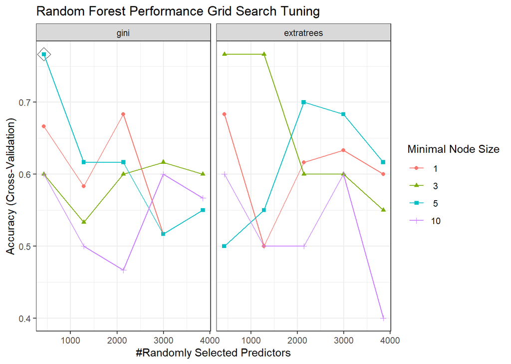

Figure 2. Visualize the Grid Search Performance

#### 2.4.1.3. Take a look at the hyperparameters of the best model.

```r
rfTuned$bestTune %>%
kable(
    format = "html",
    caption = "Table 3. Results of the Grid Search on Random Forest") %>%
    kable_styling(bootstrap_options = c("hover", full_width = F))
```

Table 3. Results of the Grid Search on Random Forest

|  | mtry | splitrule | min.node.size |
| --- | --- | --- | --- |
| 3 | 427 | gini | 5 |

#### 2.4.1.4. Fit the best model’s hyperparameters to the test data.

```r
rfTuned <- train(Treatment ~.,
               data = train,
               method = "ranger",
               trControl = kFoldCtrl,
               tuneGrid = rfTuned$bestTune)   ## Use the best model
```

#### 2.4.1.5. Make the new predictions to assess accuracy.

```r
pred.test.rf <- predict(rfTuned, test, type = "raw")  ## type is now 'raw'
# Store the confusion matrix
confMatTuned <- confusionMatrix(pred.test.rf, test$Treatment)
```

```r
compareConfusion(confusionList = list(confMatCV, confMatTuned)) %>%
    kable(
    format = "html",
    caption = "Table 4. Comparing Accuracy - Random Forest") %>%
    kable_styling(bootstrap_options = c("hover", full_width = F))
```

Table 4. Comparing Accuracy - Random Forest

| Metric | Confusion Matrix 1 | Confusion Matrix 2 |
| --- | --- | --- |
| Accuracy | 0.5000000 | 0.5000000 |
| Kappa | 0.0000000 | 0.0000000 |
| AccuracyLower | 0.0125791 | 0.0125791 |
| AccuracyUpper | 0.9874209 | 0.9874209 |
| AccuracyNull | 0.5000000 | 0.5000000 |
| AccuracyPValue | 0.7500000 | 0.7500000 |
| McnemarPValue | 1.0000000 | 1.0000000 |

#### **Question 13**: What impact did hyperparameter tuning with the grid search have on model performance compared to 5-fold CV with auto-tuning?

MH > The hyperparameter tuning did not improve over the 5-fold CV. After running several different times the models often performed the exact same. Given our suspiscions on the first model this does not bode well for this method being a preferred path.

**Note on methodology**: As I mentioned above, there is no parameter for the number of trees that we could tune in the search grid. Why not? It’s because we used the `train()` function from the `caret` package. `train()` is what is called a **wrapper function**, which means that we may be somewhat stuck using what’s available to us in the function. But what if we want to tune hyperparameters that are available through that wrapper function? We would need to switch our tactics. We could either write a **custom function or loop** to do it, or we could modify the function in `caret`. Wait, we can do that?! Yep!

#### **Question 14**: Use the `modelLookup` function to help you figure out what hyperparameters are available for the `rf` vs. `ranger` methods for performing random forest algorithm with `caret`. What are the key differences you observce in the hypers you can tune?

```r
modelLookup("ranger")
```

```
##    model     parameter                         label forReg forClass probModel
## 1 ranger          mtry #Randomly Selected Predictors   TRUE     TRUE      TRUE
## 2 ranger     splitrule                Splitting Rule   TRUE     TRUE      TRUE
## 3 ranger min.node.size             Minimal Node Size   TRUE     TRUE      TRUE
```

```r
modelLookup("rf")
```

```
##   model parameter                         label forReg forClass probModel
## 1    rf      mtry #Randomly Selected Predictors   TRUE     TRUE      TRUE
```

MH > The hyperparameters available in `rf` are only mtry, whereas for `ranger`, there is `mtry`, `splitrule` and `min.node.size`.

### 2.4.2 Grid Search Using a Customized `caret` Method

#### 2.4.2.1. Write a customized `caret` method for random forest using the `ranger` method.

MH > This function allows us to tune additional hyerparameters, define exactly ho the model is trained and gives us additional flexibility and control over the normal tuning done withing `caret`.

#### 2.4.2.2. Run the customized method.

**NOTE**: This takes about 12 min to run on 16gb of RAM. This is exactly why we are doing caching for this assignment. Otherwise, your report will take forever to re-knit.

```r
## Run the custom method setting the hyperparameters we want to use
customRF <- makeCustomMethod(paramList = c("mtry",
                                           "num.trees",
                                           "min.node.size",
                                           "splitrule"),
                             methodName = "ranger")

## Now expand the search grid
searchGrid <- expand.grid(.mtry = floor(ncol(train) * c(.05, .15, .25)),
                        .num.trees = c(50, 200),
                        .min.node.size = c(1, 5, 10, 20),
                        .splitrule = "gini"
                        )
## Now run the RF with the custom tuned hypers and the new search grid
customTuned <- train(y = train$Treatment, x = train,
                method = customRF,
                metric = "Accuracy",
                tuneGrid = searchGrid,
                trControl = kFoldCtrl)
```

#### **Question 16**: Did you catch that I am setting `.splitrule = gini` explicitly? Why do you think I made this choice?

MH > Because we already determined that `gini` was a preferred split rule, specifying here can reduce the number of hyperparameters the function is testing.

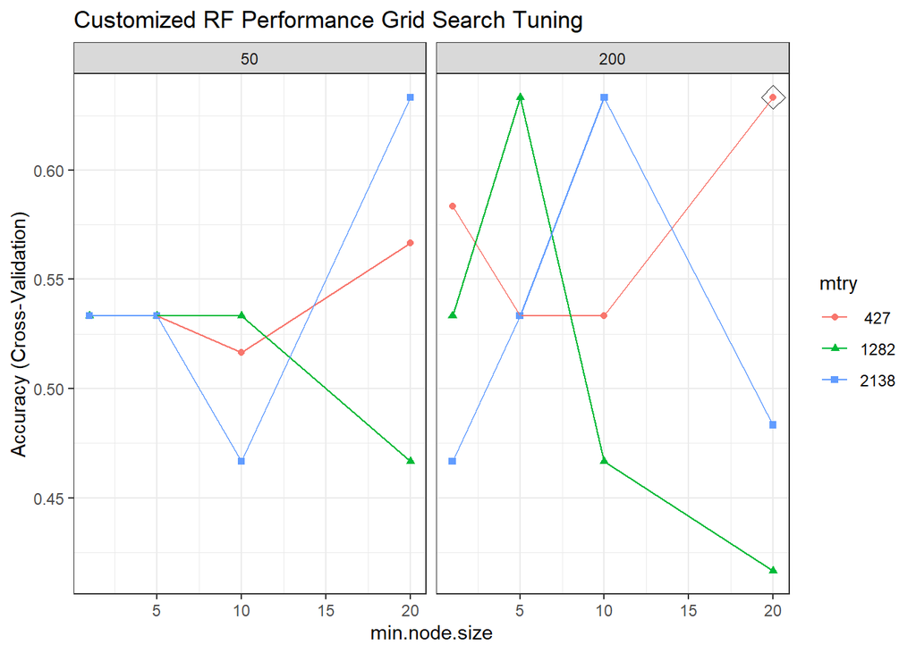

Figure 3. Visualize the Customized Grid Search Performance

#### 2.4.2.3. Take a look at the hyperparameters of the best model.

```r
customTuned$bestTune %>%
kable(
    format = "html",
    caption = "Table 4. Results of the Customized Grid Search on Random Forest") %>%
    kable_styling(bootstrap_options = c("hover", full_width = F))
```

Table 4. Results of the Customized Grid Search on Random Forest

|  | mtry | num.trees | min.node.size | splitrule |
| --- | --- | --- | --- | --- |
| 8 | 427 | 200 | 20 | gini |

#### 2.4.2.4. Refit the best model’s hyperparameters to the test data set.

```r
newTuned <- train(Treatment ~.,
               data = train,
               method = customRF,
               trControl = kFoldCtrl,
               tuneGrid = customTuned$bestTune)
```

#### 2.4.2.5. Make the new predictions to assess accuracy.

```r
pred.test.rf <- predict(newTuned, test, type = "raw")
# Store the confusion matrix
confMatTuned2 <- confusionMatrix(pred.test.rf, test$Treatment)
```

Table 4. Comparing Accuracy - Random Forest

| Metric | Confusion Matrix 1 | Confusion Matrix 2 | Confusion Matrix 3 |
| --- | --- | --- | --- |
| Accuracy | 0.5000000 | 0.5000000 | 0.5000000 |
| Kappa | 0.0000000 | 0.0000000 | 0.0000000 |
| AccuracyLower | 0.0125791 | 0.0125791 | 0.0125791 |
| AccuracyUpper | 0.9874209 | 0.9874209 | 0.9874209 |
| AccuracyNull | 0.5000000 | 0.5000000 | 0.5000000 |
| AccuracyPValue | 0.7500000 | 0.7500000 | 0.7500000 |
| McnemarPValue | 1.0000000 | 1.0000000 | 1.0000000 |

#### **Question 18**: How well did hyperparameter tuning with the number of trees and the new grid search perform? Are we seeing sufficient improvement to continue down this path?

**Hint**: Make sure to check model stability again as well by looking at the performance across folds, even though I didn’t do that for you.

MH

```r
#Checking fold accuracy for newTuned model
newTuned$resample
```

```
##    Accuracy Kappa Resample
## 1 0.7500000   0.5    Fold1
## 2 0.6666667   0.0    Fold2
## 3 1.0000000   1.0    Fold3
## 4 0.3333333  -0.5    Fold4
## 5 1.0000000   1.0    Fold5
```

> The confusion matrix resulted in each of the models performing the exact same. Again, given the size of dataset, and the concerns we had previously, as well as the random (and dramatic) changes and variability we see after rerunning the model several times, continuing down the path of hyperparameter turning does not seem to be a promising method for such a small dataset.

### 2.4.3 Random Search

A random search is where we randomly choose hyperparameters and, based on an initial set of random values, iteratively search until we get closer and closer to the best fit. Now, at this point we might also consider performing a random search in addition to the grid search; however, as we can see that we are generally STILL seriously under-performing, let’s table that idea and put our efforts somewhere we will hopefully see a bigger impact: **Nested Cross-Validation**.

## 2.5 Nested Cross-Validation

As we have already discussed in lecture and Demo_3, the norm in machine learning is to have a lot more observations ($n$) than the number of features ($P$). Although it is tempting to think the same thing here, remember that the columns here are not features but rather samples, giving us a $P >> N$ problem.

Whenever $P >> N$ as here, our typical approaches for cross-validation must change. We have several options, but here we will employ a **nested cross-validation** approach. Other options would include a hold out or leave-one-out, although with some caveats.

**You will find that this method is not employed as much as it should be yet in gene expression analysis.** Why? Conceptually, this may be a bit hard to understand - and ML methods are already really different from what is done with the conventional methods like `DESeq2`. Let’s go over what nested CV is to try to unpack this a little.

### 2.5.2 The `nestedcv` package

Although we can also execute this with custom functions or loops, it’s usually going to be far more expedient to leverage a pre-existing package. Here, we will use the `nestedcv` package.

`nestedcv` partitions the dataset into outer and inner folds, with the default being 10-fold outer CV and 10-fold inner CV, also called **10 x 10 folds** CV. The inner-fold cross validation tunes the optimal hyperparameters for whatever model(s) are run. The model is then fitted on the whole inner-fold and tested against the left-out data from the outer-fold. This is repeated across all outer-folds. Then, the test predictions from the outer-folds are compared against the true results for the test outer-folds. The combined results give a measure of accuracy for the whole dataset as you are accustomed, e.g., either RMSE for regression or AUC for classification.

Lastly, a final round of cross-validation is performed on the whole dataset to determine hyperparameters to fit the final model to the whole data, which can be used for prediction with external data (which could be yet another test set you have withheld, for example, as we’ve been doing).

**Whew!**

### 2.5.3 Running a Nested CV

#### 2.5.3.1. Set a search grid and train the model using the `nestedcv.train()` function.

Note that the setup looks a little reminiscent of our customized `caret` function. That’s because the authors of this package are doing something similar, although they have improved the computational speed. We could do that too - **if** we wanted to write a package. Otherwise, we can just let ours run and take a coffee/tea break. :)

**IMPORTANT!**: We are not able to use $m_{try}$ as large as we are used to because we’re doing inner- and outer-folds. We lowered $m_{try}$ here as a result. If you are doing this on different data and you get an error, that’s something to look into!

**Note**: This took 14 mins on 16gb RAM, depending on what else I was asking my computer to do at the same time.

```r
searchGrid <- expand.grid(.mtry = floor(ncol(train) * c(0.01, 0.05, 0.10)),
                        .min.node.size = c(1, 5, 10),

                        .splitrule = "gini"
                        )
ncv <- nestcv.train(y = train$Treatment, x = train,
                    method = 'ranger',
                    tuneGrid = searchGrid,
                    savePredictions = "final")
```

```
## 1 predictor(s) have var=0
```

```
## Fitting final model using CV on whole data
```

```
## Performing 10-fold outer CV, using 1 core
```

```
## Duration: 12.96389 mins
```

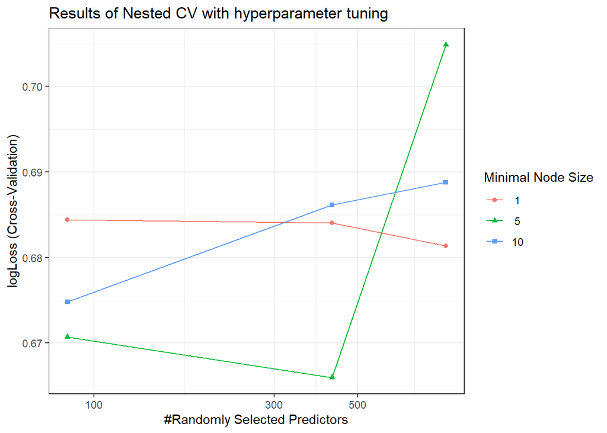

Figure 4. Visualize the Nested CV Performance on RF + Grid Search

#### **Question 19**: Notice that the y-axis is now **log-Loss** and not **accuracy**. You may need to do some digging, but can you figure out why? Citing sources can be helpful to ensure you’re on the right track!

MH > According to the R documentation for nested cross-validation for caret, ‘logLoss’ is the default metric for classification rather than ‘Accuracy’ which is the default classification metric in caret.According to the R documentation, “LogLoss is arguably more consistent than Accuracy for tuning parameters in datasets with small sample size.” Source: https://search.r-project.org/CRAN/refmans/nestedcv/html/nestcv.train.html

**Note**: You’re going to see something really weird here…

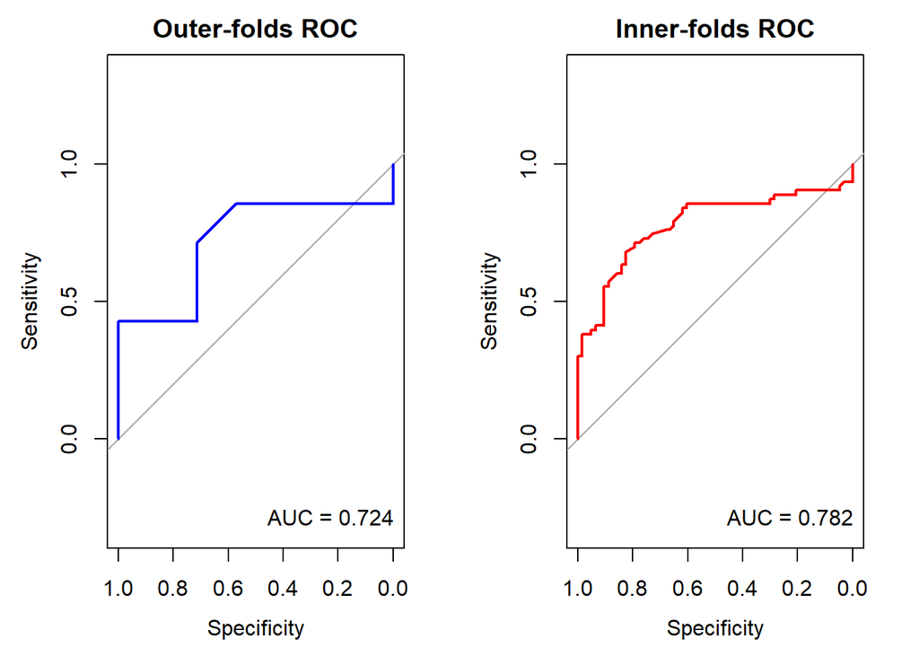

#### 2.5.3.3. Get final accuracy by fitting to the test data.

```r
preds <- predict(ncv,
                 newdata = test)
confusionMatrix(preds, test$Treatment)
```

```
## Confusion Matrix and Statistics
##
##           Reference
## Prediction Control Cold
##    Control       0    0
##    Cold          1    1
##
##                Accuracy : 0.5
##                  95% CI : (0.0126, 0.9874)
##     No Information Rate : 0.5
##     P-Value [Acc > NIR] : 0.75
##
##                   Kappa : 0
##
##  Mcnemar's Test P-Value : 1.00
##
##             Sensitivity : 0.0
##             Specificity : 1.0
##          Pos Pred Value : NaN
##          Neg Pred Value : 0.5
##              Prevalence : 0.5
##          Detection Rate : 0.0
##    Detection Prevalence : 0.0
##       Balanced Accuracy : 0.5
##
##        'Positive' Class : Control
##
```

**Hint**: Make sure to mention why/when ROC curves can be misleading.

#### **Question 21**: Using help from generative AI or search engines, figure out how to assess the **stability** of the model across the nested folds. What conclusions can you draw? Write a 1-2 sentence conclusion for your stakeholders about whether or not you think the random forest is tuneable and what you’d recommend next.

DS > The way we can assess stability are visually and tracking different intervals with parameter values to see if there is a somewhat constant range with the model. We’ve found out there isn’t a consistant range like we’d hoped to have. We’ll need to jump back into our samples and try to gain more from there being errors with flucuations in results due to how small our observation size is.

#### 2.5.3.4. Grab the important features.

Even if you decided that model performance is still poor and that you’d not recommend continuing with the RF, let’s practice grabbing the important features so you have code to do it.

Table 5. Important Features from the Nested CV Grid Search on Random Forest

|  | MeanDecreaseGini |
| --- | --- |
| LOC100747964 | 2.604766 |
| LOC100740290 | 2.401905 |
| LOC100749925 | 2.182780 |
| LOC100746744 | 2.070967 |
| LOC100745328 | 1.967760 |
| LOC100747847 | 1.963374 |
| LOC100740004 | 1.956348 |
| LOC100740440 | 1.724450 |
| LOC100740861 | 1.711000 |
| LOC100742105 | 1.700201 |

#### 2.5.3.5. Compare our gene results to the ones out of `DESeq2`.

Remember, the ultimate goal was to see which ML method was getting us close to results from `DESeq2`, the respected, conventional method.

Let’s filter the nested CV random forest importance:

Now let’s compare that to what we got out of `DESeq2`.

**Note** that I am setting a log-fold change filter to 1. In other words… any gene! Am I going to get any credible results?

Table 6. Overlapping Features identified from DESeq and Nested CV Random Forest

| baseMean | log2FoldChange | lfcSE | stat | pvalue | padj | geneID | MeanDecreaseGini |
| --- | --- | --- | --- | --- | --- | --- | --- |
| 7.681726 | 1.205839 | 0.4515818 | 2.670255 | 0.0075794 | 0.1822530 | LOC100740440 | 1.724450 |
| 10.321264 | 1.045521 | 0.4722053 | 2.214124 | 0.0268203 | 0.3118604 | LOC100747341 | 1.657303 |
| 18.570866 | -1.279571 | 0.4619817 | -2.769744 | 0.0056100 | 0.1641258 | LOC100745314 | 1.415630 |
| 3.776269 | 1.630086 | 0.5848077 | 2.787388 | 0.0053135 | 0.1617796 | LOC100743721 | 1.406954 |
| 3902.434875 | -4.084690 | 0.9200610 | -4.439587 | 0.0000090 | 0.0133650 | LOC100747885 | 1.373282 |
| 16.598975 | -1.993485 | 0.5272589 | -3.780847 | 0.0001563 | 0.0428296 | LOC100743629 | 1.228808 |
| 7.417068 | -1.355645 | 0.4274490 | -3.171477 | 0.0015167 | 0.1062497 | LOC100746079 | 1.000500 |
| 48.386081 | 1.074916 | 0.4001588 | 2.686224 | 0.0072265 | 0.1779960 | LOC100740081 | 1.000500 |
| 18.751964 | -1.526869 | 0.4053617 | -3.766684 | 0.0001654 | 0.0428296 | LOC100742047 | 1.000500 |
| 13.624542 | 1.209591 | 0.4585621 | 2.637791 | 0.0083448 | 0.1908576 | LOC100743699 | 1.000500 |
| 39063.523498 | -1.945027 | 0.8652256 | -2.248000 | NA | NA | LOC100745814 | 1.000500 |
| 58.902533 | -2.890835 | 0.6078527 | -4.755815 | 0.0000020 | 0.0087924 | LOC100747405 | 1.000500 |
| 165.426575 | -3.578099 | 0.7964588 | -4.492509 | 0.0000070 | 0.0125250 | LOC100748162 | 1.000500 |
| 6.847508 | 1.071147 | 0.4096970 | 2.614487 | 0.0089362 | 0.1977737 | LOC100749318 | 1.000500 |
| 37.516296 | 1.052042 | 0.4235998 | 2.483576 | 0.0130071 | 0.2308078 | LOC112213654 | 1.000500 |
| 10.070702 | -1.516155 | 0.4915366 | -3.084521 | 0.0020388 | 0.1170010 | LOC100747948 | 1.000500 |

**IMPORTANT!** I have had this list reshuffle on me. I believe the issue is with the `rf_filter()` function we’re using, and is something to consider for reproducibility!

#### 2.5.3.6. Find out what our top gene from nested CV random forest does.

#### **Question 22**: Do you think we should we have any confidence in these results? Why or why not? Think about this from the perspective of what you would tell/advise your stakeholder.

Love, Michael I., Wolfgang Huber, and Simon Anders. 2014. “Moderated Estimation of Fold Change and Dispersion for RNA-Seq Data with DESeq2.” *Genome Biology* 15 (12): 550. https://doi.org/10.1186/s13059-014-0550-8.

R Core Team. 2019. *R: A Language and Environment for Statistical Computing*. R Foundation for Statistical Computing. https://www.R-project.org.

Vabalas, Emma AND Poliakoff, Andrius AND Gowen. 2019. “Machine Learning Algorithm Validation with a Limited Sample Size.” *PLOS ONE* 14 (11): 1–20. https://doi.org/10.1371/journal.pone.0224365.

Verble, Kelton M., Ellen C. Keaveny, Sarthok Rasique Rahman, Matthew J. Jenny, Michael E. Dillon, and Jeffrey D. Lozier. 2024. “A Rapid Return to Normal: Temporal Gene Expression Patterns Following Cold Exposure in the Bumble Bee *Bombus Impatiens*.” *Journal of Experimental Biology* 227 (9): jeb247040. https://doi.org/10.1242/jeb.247040.